# Small Claims: Canadian County 00-19

Leticia, Fellow

Open Justice Oklahoma

2021-05-17

Background information: Why are we researching this topic? What is the expected product? A blog post? Analysis for an internal or external partner?

This project aims to shed light on the extent of medical debt in Oklahoma. The goal is to produce blog posts, fact sheets, and/or reports that emphasize the scale of the medicial debt problem in Oklahmoa and urge citizens to vote in favor of SQ 802.

# 1 Data sources

Where is the data from? The ojo database? OSCN? ODCR? Crime in Oklahoma reports?

The data is from the ojo database.

## 1.1 Timeframe

What years/months are you looking at? Year of case filing, first disposition, prison admission, etc.? Be as specific as possible.

The analysis aims to identify trends in medical debt cases over the past 20 years (2000-2019).

## 1.2 Geography

What courts/counties/states are you looking at?

This analysis focuses on small claims court cases in Canadian County.

## 1.3 Variables

What variables did you use? What types of cases, crimes, etc.?

This project focuses on medical debt cases.

## 1.4 Query

If you’re using data from the OJO database, include the query you used to pull your data. This may be a function that starts `ojo_query_` or `dbGetQuery`.

```r
sc <- ojo_query_disps("CANADIAN", "SC", 2000:2019)
```

This gives us over 43,938 rows of data. Each row in the table is a disposition; since there may be multiple dispositions per case, we should expect that the number of cases is somewhat lower.

# 2 Checking Data

## 2.1 Check for Completeness

If you’re using court data, you can use the `ojo_check_comp` to see how complete the data is.

```r
#ojo_check_comp(sc)

#completeness
```

## 2.2 Check for NAs

Detail the NAs and blank items in your data and, if necessary and possible, fill them in.

```r
nas <- sc %>%
  group_by(casenum) %>%
  filter(all(is.na(iss_plaint) | iss_plaint == ""))

nas
```

```
## # A tibble: 2,133 x 12
## # Groups:   casenum [1,758]
##    court  casenum   casetype file_year file_date  defname       iss_no iss_desc
##    <chr>  <chr>     <chr>        <int> <date>     <chr>         <chr>  <chr>
##  1 CANAD… SC-2000-… SC            2000 NA         MARTIN, JAMES 1      INDEBTED…
##  2 CANAD… SC-2000-… SC            2000 NA         HATTEN, ORLA… 1      INDEBTED…
##  3 CANAD… SC-2000-… SC            2000 NA         COLLIS, STEVE 1      INDEBTED…
##  4 CANAD… SC-2000-… SC            2000 NA         COMETSEVAH, … 1      INDEBTED…
##  5 CANAD… SC-2000-… SC            2000 NA         DOUGLAS, ARV… 1      INDEBTED…
##  6 CANAD… SC-2000-… SC            2000 NA         WATTS, BRAND… 1      INDEBTED…
##  7 CANAD… SC-2000-… SC            2000 NA         BAKER, HOMER… 1      INDEBTED…
##  8 CANAD… SC-2000-… SC            2000 NA         BAKER, JAY    1      INDEBTED…
##  9 CANAD… SC-2000-… SC            2000 NA         SLEEPER, KEN… 1      INDEBTED…
## 10 CANAD… SC-2000-… SC            2000 NA         GUTHRIE, DAR… 1      INDEBTED…
## # … with 2,123 more rows, and 4 more variables: iss_plaint <chr>,
## #   disp_date <date>, disp <chr>, disp_type <chr>
```

```r
nas_desc <- sc %>%
  group_by(casenum) %>%
  filter(all(is.na(iss_desc) | iss_desc == ""))

nas_desc
```

```
## # A tibble: 29 x 12
## # Groups:   casenum [23]
##    court   casenum    casetype file_year file_date  defname      iss_no iss_desc
##    <chr>   <chr>      <chr>        <int> <date>     <chr>        <chr>  <chr>
##  1 CANADI… SC-2000-0… SC            2000 NA         MILES, MARL… 1      ""
##  2 CANADI… SC-2000-0… SC            2000 NA         WILEY, MIKE  1      ""
##  3 CANADI… SC-2000-0… SC            2000 NA         MILLER, EDW… 1      ""
##  4 CANADI… SC-2000-0… SC            2000 NA         COLLINS, ST… 1      ""
##  5 CANADI… SC-2000-0… SC            2000 NA         COLLINS, DA… 1      ""
##  6 CANADI… SC-2000-0… SC            2000 NA         PULLEN, ANG… 1      ""
##  7 CANADI… SC-2000-0… SC            2000 NA         BERRY, JOE   1      ""
##  8 CANADI… SC-2000-0… SC            2000 NA         HAMILL, MAR… 1      ""
##  9 CANADI… SC-2000-0… SC            2000 NA         THOMPSON, J… 1      ""
## 10 CANADI… SC-2000-0… SC            2000 NA         VAUGHN, CLA… 1      ""
## # … with 19 more rows, and 4 more variables: iss_plaint <chr>,
## #   disp_date <date>, disp <chr>, disp_type <chr>
```

Next, we will add the debt amounts to our dataset.

## 2.3 Extract debt amount from minutes

```r
mins <- ojo_query_mins("CANADIAN", "SC", 2000:2019, min_code = "A/")
```

```
## [1] "SC 2000 minutes queried for OSCN courts: CANADIAN"
## [1] "SC 2001 minutes queried for OSCN courts: CANADIAN"
## [1] "SC 2002 minutes queried for OSCN courts: CANADIAN"
## [1] "SC 2003 minutes queried for OSCN courts: CANADIAN"
## [1] "SC 2004 minutes queried for OSCN courts: CANADIAN"
## [1] "SC 2005 minutes queried for OSCN courts: CANADIAN"
## [1] "SC 2006 minutes queried for OSCN courts: CANADIAN"
## [1] "SC 2007 minutes queried for OSCN courts: CANADIAN"
## [1] "SC 2008 minutes queried for OSCN courts: CANADIAN"
## [1] "SC 2009 minutes queried for OSCN courts: CANADIAN"
## [1] "SC 2010 minutes queried for OSCN courts: CANADIAN"
## [1] "SC 2011 minutes queried for OSCN courts: CANADIAN"
## [1] "SC 2012 minutes queried for OSCN courts: CANADIAN"
## [1] "SC 2013 minutes queried for OSCN courts: CANADIAN"
## [1] "SC 2014 minutes queried for OSCN courts: CANADIAN"
## [1] "SC 2015 minutes queried for OSCN courts: CANADIAN"
## [1] "SC 2016 minutes queried for OSCN courts: CANADIAN"
## [1] "SC 2017 minutes queried for OSCN courts: CANADIAN"
## [1] "SC 2018 minutes queried for OSCN courts: CANADIAN"
## [1] "SC 2019 minutes queried for OSCN courts: CANADIAN"
```

```r
mins <- mins %>%
  mutate(debt_amt = min_desc %>%
           str_remove_all("[:alpha:]|\\$|,") %>%
           str_squish %>%
           as.numeric)


debt_amts <- mins %>%
  select(casenum, debt_amt)
```

```r
new <- left_join(sc, debt_amts, by= "casenum")

sc <- new
```

Summarize by case level

```r
#sc <- sc %>%
  #group_by(casenum) %>%
  #slice(1)
```

There are 34,545 small claims cases.

# 3 Defining Measures

## 3.1 Debt Cases

Small claims cases generally involve an eviction (called “Forcible Entry and Detainer”) or a debt of less than $5,000. To narrow down our data set, we’ll limit to cases that involve debt.That information is found in the issue description (iss_desc) column.

```r
sc %>%
  count(iss_desc) %>%
  arrange(desc(n))
```

```
##                                                          iss_desc     n
## 1                                                    INDEBTEDNESS 20751
## 2                                       FORCIBLE ENTRY & DETAINER 12929
## 3                                            INDEBTEDNESS >$1500.  6941
## 4                               FORCIBLE ENTRY & DETAINER >$1500.  1841
## 5                              BREACH AGREEMENT - CONTRACT>$1500.   269
## 6                                     BREACH AGREEMENT - CONTRACT   261
## 7                                         INDEBTEDNESS >$5000.00.   155
## 8                                               DAMAGES >$1500.00    85
## 9                                  AFFIDAVIT FOR REPLEVIN >$1500.    74
## 10                                                          OTHER    70
## 11                                         AFFIDAVIT FOR REPLEVIN    67
## 12                                                        DAMAGES    62
## 13                                                   INTERPLEADER    61
## 14                                  AUTOMOBILE NEGLIGENCE >$1500.    49
```

[output cut: 46 more lines]

We see that over 12,925 cases are evictions. We can discard those.

We use the str_detect() function to look for rows with the character string “FORC” in order to catch both “FORCIBLE ENTRY & DETAINER” and “FORCIBLE ENTRY & DETAINER >$1500”, plus any others that may be similar. Putting a ! before it means we want the rows where the string is not detected.

```r
debt <- sc %>%
  filter(!str_detect(iss_desc, "FORC|REPLEVIN|BREACH"))

debt %>%
  count(iss_desc) %>%
  arrange(desc(n))
```

```
##                                                          iss_desc     n
## 1                                                    INDEBTEDNESS 20751
## 2                                            INDEBTEDNESS >$1500.  6941
## 3                                         INDEBTEDNESS >$5000.00.   155
## 4                                               DAMAGES >$1500.00    85
## 5                                                           OTHER    70
## 6                                                         DAMAGES    62
## 7                                                    INTERPLEADER    61
## 8                                   AUTOMOBILE NEGLIGENCE >$1500.    49
## 9                                           AUTOMOBILE NEGLIGENCE    38
## 10                                                                   29
## 11                                                   COUNTERCLAIM    28
## 12                                         COUNTERCLAIM OR SETOFF    27
## 13                                        PROMISSORY NOTE >$1500.    19
## 14                                           NEGLIGENCE >$1500.00    17
```

[output cut: 33 more lines]

Medical debt cases will be filed with “Indebtedness” issues only. We discard all other cases.

```r
debt <- debt %>%
  filter(str_detect(iss_desc, "DEBT"))

debt %>%
  count(iss_desc) %>%
  arrange(desc(n))
```

```
##                            iss_desc     n
## 1                      INDEBTEDNESS 20751
## 2              INDEBTEDNESS >$1500.  6941
## 3           INDEBTEDNESS >$5000.00.   155
## 4               INDEBT 1 < $1500.00     4
## 5 INDEBTEDNESS >$1500./COUNTERCLAIM     2
## 6                          INDEBT 1     1
## 7             INDEBTEDNESS < $1500.     1
## 8            INDEBTEDNESS >$1500.00     1
## 9                    INDEBTEDNESS 1     1
```

## 3.2 Medical Providers

Next, we will use the mutate() function to classify the cases that have a medical provider plaintiff.

Let’s start by finding the most common plaintiffs:

```r
debt %>%
  count(iss_plaint) %>%
  arrange(desc(n))
```

```
##                                              iss_plaint    n
## 1                             INTEGRIS RURAL HEALTH INC 4023
## 2                                                       1518
## 3                                    CITY NATIONAL BANK 1471
## 4            INTEGRIS CANADIAN VALLEY REGIONAL HOSPITAL 1452
## 5                                           TOWER LOANS 1155
## 6                   INTEGRIS BAPTIST MEDICAL CENTER INC 1114
## 7                                        COURTESY LOANS 1021
## 8                          BREIT INVESTMENT CORPORATION  846
## 9                          WORLD ACCEPTANCE CORPORATION  774
## 10                           CITIFINANCIAL SERVICES INC  710
## 11                                BREIT INVESTMENT CORP  615
## 12                                       AMERICAN LOANS  594
## 13                                    THE BANK OF UNION  569
## 14                                   PARK VIEW HOSPITAL  531
```

[output cut: 2230 more lines]

Many of the most common plaintiffs are clearly medical providers or financial institutions. We use the case_when() function to classify all rows where one of the words is detected as being filed by a medical provider.

```r
debt <- debt %>%
  mutate(plaint_type = case_when(str_detect(iss_plaint, "HEALTH|CLINIC|MEDICAL") ~ "MEDICAL",
                                 str_detect(iss_plaint, "BANK|FCU") ~ "OTHER",
                                 TRUE ~ "UNKNOWN"))
```

To check how many we were able to classify, we’ll look at the count in the plaint_type column.

```r
debt %>%
  count(plaint_type) %>%
  arrange(desc(n))
```

```
##   plaint_type     n
## 1     UNKNOWN 19282
## 2     MEDICAL  6169
## 3       OTHER  2406
```

To classify the remaining 19,282 cases, we comb through the plaintiffs and classify them. We can repeat the three steps above until we have enough of them classified.

To get the most common plaintiffs that are not classified yet:

```r
debt %>%
  filter(plaint_type == "UNKNOWN") %>%
  count(iss_plaint) %>%
  arrange(desc(n))
```

```
##                                              iss_plaint    n
## 1                                                       1518
## 2            INTEGRIS CANADIAN VALLEY REGIONAL HOSPITAL 1452
## 3                                           TOWER LOANS 1155
## 4                                        COURTESY LOANS 1021
## 5                          BREIT INVESTMENT CORPORATION  846
## 6                          WORLD ACCEPTANCE CORPORATION  774
## 7                            CITIFINANCIAL SERVICES INC  710
## 8                                 BREIT INVESTMENT CORP  615
## 9                                        AMERICAN LOANS  594
## 10                                   PARK VIEW HOSPITAL  531
## 11                                   COURTESY LOANS INC  520
## 12                                      TOWER LOANS INC  378
## 13                                        YUKON FINANCE  373
## 14                                         HOME FINANCE  273
```

[output cut: 2150 more lines]

I came up with the following classification:

```r
debt <- debt %>%
  mutate(plaint_type = case_when(str_detect(iss_plaint, "HEALTH|CLINIC|MEDICAL|HOSPITAL|INTEGRIS| DPM| DDS|MEDICINE|DENTAL|ORTHOPAEDIC|FOOT\\sAND\\sANKLE|D\\.P\\.M\\.|PHYSICIANS|RADIOLOGY|D\\.D\\.S\\.|SURGICAL|OPTOMETRISTS|COMPLETE\\sREHAB\\sINC|CHIROPRACTIC|YUKON\\sWOUND\\sCARE\\s&\\sREHAB|YUKON\\sWOUND\\sCARE\\sAND\\sREHABILITATION") ~ "MEDICAL",
                                 str_detect(iss_plaint, "BANK|FCU|CREDIT|LOAN|FINANCIAL|INVESTMENT|WORLD\\sACCEPTANCE\\sCORP|CITIFINANCIAL|FINANCE|CASH|CHECK|KIDS\\sKLUB|ENVIRONMENTAL|BRONCOS|WESTERN\\sSHAMROCK|MILLERS\\sGATE\\sHOA|VALUED\\sSERVICES\\sOF\\sOKLAHOMA|OSBY\\s&\\sMILLER| HOA|THE\\sLITTLE\\sDIRECTORY|HEAT\\s&\\sAIR|PROPERTY|BRIGHT\\sBEGINNINGS|OIL|RAMEY\\s&\\sTHARP|HOMEOWNERS|GROWING\\sTHE\\sFUTURE|SEED|PEANUT\\sBUTTER\\s&\\sJELLY\\sDAYCARE|CHILD\\sCARE\\sACADEMY|LAWNCARE|HANDLEY\\sLAW\\sCENTER|CONCRETE|ADVANCE\\sAMERICA|ELEVATOR ASSOCIATION|DRIVER\\sTRAINING|WEST\\sYUKON\\sANIMAL\\sHOSPITAL|CANADIAN\\sVALLEY\\sANIMAL\\sCLINIC|YUKON\\sVETERINARY\\sHOSPITAL\\sINC|YUKON\\sVETERINARY\\sHOSPITAL") ~ "OTHER",
                                 TRUE ~ "UNKNOWN"))
```

This gives us a count of:

```r
debt %>%
  count(plaint_type) %>%
  arrange(desc(n))
```

```
##   plaint_type     n
## 1       OTHER 13593
## 2     MEDICAL  9240
## 3     UNKNOWN  5024
```

```r
debt %>%
  filter(plaint_type == "UNKNOWN") %>%
  count(iss_plaint) %>%
  arrange(desc(n))
```

```
##                                              iss_plaint    n
## 1                                                       1518
## 2                          OKLAHOMA TRAINING CENTER INC  199
## 3                                        REVIEW NEWS CO   31
## 4                            WELCOME HOME COMMUNITY LLC   18
## 5                                          NAUS, GARY E   15
## 6                              OKLAHOMA TRAINING CENTER   14
## 7                                     SORRELLS, RANDALL   14
## 8                                         CITY OF YUKON   13
## 9                    SOUTHWEST TRAILERS & EQUIPMENT LLC   13
## 10                               HANDLEY, FLETCHER D JR   12
## 11                                 WILHITE, MICHAEL DEE   12
## 12                                      ARC HOUSING LLC   11
## 13                          DIFFEE FORD LINCOLN MERCURY   11
## 14                                                 EMSA   11
```

[output cut: 1847 more lines]

This gives us the most common medical plaintiffs:

```r
debt %>%
  filter(plaint_type == "MEDICAL") %>%
  count(iss_plaint) %>%
  arrange(desc(n))
```

```
##                                             iss_plaint    n
## 1                            INTEGRIS RURAL HEALTH INC 4023
## 2           INTEGRIS CANADIAN VALLEY REGIONAL HOSPITAL 1452
## 3                  INTEGRIS BAPTIST MEDICAL CENTER INC 1114
## 4                                   PARK VIEW HOSPITAL  531
## 5                 EMERGENCY MEDICAL SERVICES AUTHORITY  457
## 6           INTEGRIS SOUTH OKLAHOMA CITY HOSPITAL CORP  177
## 7                 INTEGRIS AMBULATORY CARE CORPORATION  101
## 8                        NORMAN REGIONAL HEALTH SYSTEM   90
## 9                      INTEGRIS BAPTIST MEDICAL CENTER   84
## 10               INTEGRIS SOUTHWEST MEDICAL CENTER INC   72
## 11                          WEST YUKON ANIMAL HOSPITAL   66
## 12                            JOHN J DITMARS JR DPM PC   65
## 13                                   PARKVIEW HOSPITAL   65
## 14                           DITMARS, JOHN J JR DPM PC   50
```

[output cut: 122 more lines]

To get a data frame with only the medical debt cases, filter on the plaint_type variable we created.

```r
debt <- debt %>%
  filter(plaint_type == "MEDICAL")
```

# 4 Summarizing and Visualizing Data

## 4.1 Summarizing to the case level

```r
debt <- debt %>%
  group_by(casenum) %>%
  slice(1)
```

That gives us 6,686 lawsuits filed.

## 4.2 Summarizing by year

```r
year_sum <- debt %>%
  ungroup %>%
  count(file_year)

year_sum
```

```
## # A tibble: 20 x 2
##    file_year     n
##        <int> <int>
##  1      2000    18
##  2      2001   169
##  3      2002   207
##  4      2003   152
##  5      2004    68
##  6      2005   218
##  7      2006   353
##  8      2007   434
##  9      2008   560
## 10      2009   414
## 11      2010   581
## 12      2011   365
## 13      2012   405
## 14      2013   401
## 15      2014   412
## 16      2015   355
## 17      2016   447
## 18      2017   360
## 19      2018   503
## 20      2019   264
```

Now we have a data frame with the number of cases filed in each year. To create a simple line plot with this data:

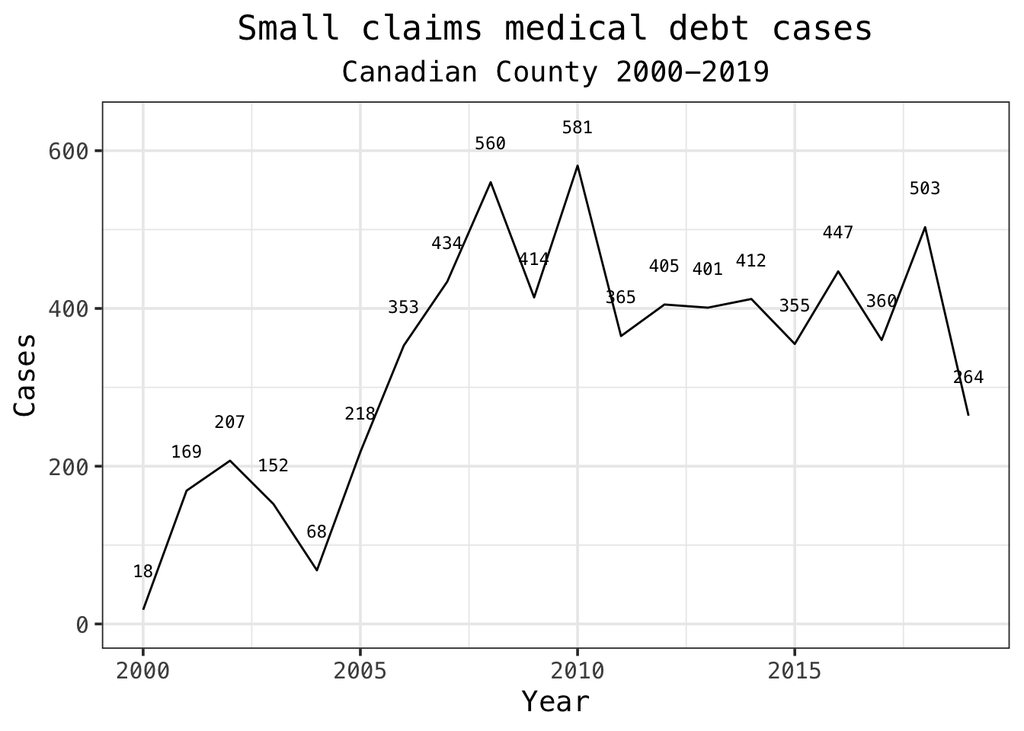

```r
ggplot(year_sum, aes(file_year, n)) +
  geom_line() +
  geom_text(aes(y = n + 50, label = n), family = "Menlo", size = 3) +
  xlab("Year") + ylab("Cases") +
  ylim(0, NA) +
  theme_ojo() +
  theme(plot.title = element_text(hjust = 0.5)) +
  theme(plot.subtitle = element_text(hjust = 0.5)) +
  labs(title = "Small claims medical debt cases",
       subtitle = "Canadian County 2000-2019")
```

##summarizing by provider The most common plaintiffs seem to be INTEGRIS, PARK VIEW HOSPITAL, & EMERGENCY MEDICAL SERVICES AUTHORITY. Again, we’ll use the str_detect() function to classify the cases.

```r
debt <- debt %>%
  mutate(plaint_cat = case_when(str_detect(iss_plaint, "INTEGRIS") ~ "INTEGRIS",
                                str_detect(iss_plaint, "PARK VIEW HOSPITAL") ~ "PARK VIEW HOSPITAL",
                                str_detect(iss_plaint, "EMERGENCY MEDICAL SERVICES AUTHORITY") ~ "EMERGENCY MEDICAL SERVICES AUTHORITY",
                                TRUE ~ "OTHER"))
```

Now we can see how many cases each group filed each year:

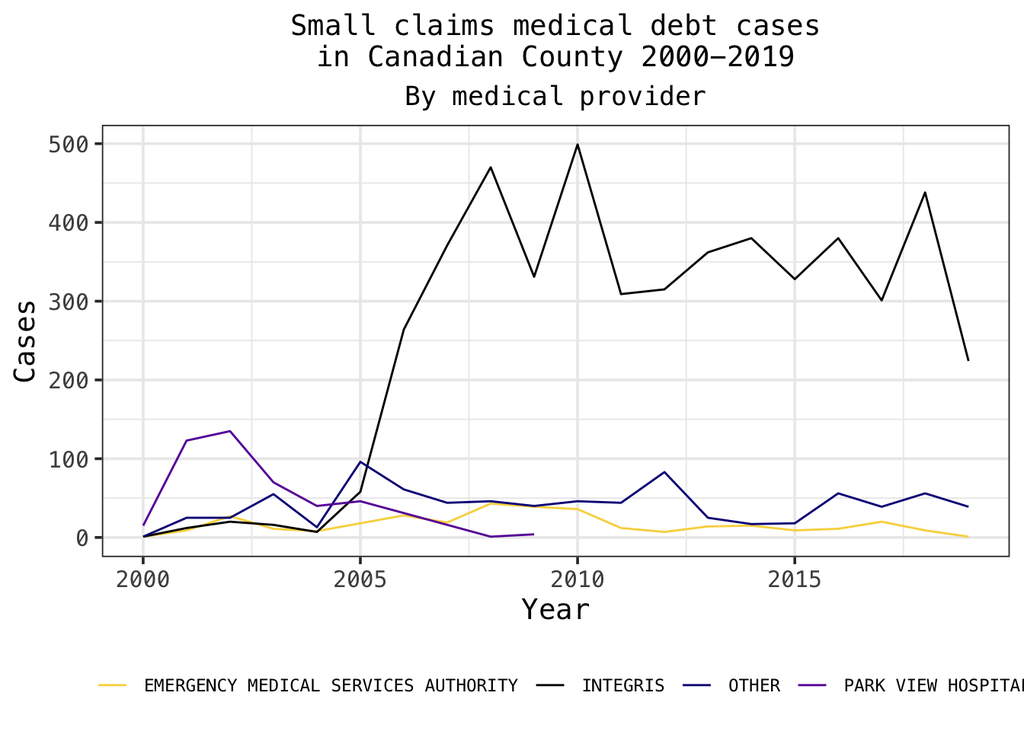

```r
plaint_sum <- debt %>%
  ungroup %>% # Our data frame is still grouped by casenum from the code above; ungroup to summarize using broader groups
  count(file_year, plaint_cat)


ggplot(plaint_sum, aes(file_year, n, group = plaint_cat, color = plaint_cat)) +
  geom_line() +
  xlab("Year") + ylab("Cases")+
  ylim(0, NA) + # Extends y-axis down to zero
  theme_ojo() + # Adds ojo styling to the plot
  theme(legend.title=element_blank())+
  theme(plot.title = element_text(hjust = 0.5, size = 14)) +
  theme(plot.subtitle = element_text(hjust = 0.5, size = 13)) +
  theme(legend.text=element_text(size = 8.5))+
  theme(legend.position="bottom")+
  labs(title = "Small claims medical debt cases\nin Canadian County 2000-2019",
       subtitle = "By medical provider") +
  scale_color_manual(values = ojo_pal) # Gives lines colors from ojo's palette
```

### Find median debt amount

Created a new dataframe with the median medical debt amount by file_year.

```r
debt_new <-debt %>%
  group_by(file_year) %>%
  summarise(n_cases = n(),
            n_cases_with_debt = sum(!is.na(debt_amt)),
            avg = median(debt_amt, na.rm = TRUE)) %>%
  mutate(pct_with_debt = n_cases_with_debt/n_cases)

debt_new
```

```
## # A tibble: 20 x 5
##    file_year n_cases n_cases_with_debt   avg pct_with_debt
##        <int>   <int>             <int> <dbl>         <dbl>
##  1      2000      18                 0    NA             0
##  2      2001     169                 0    NA             0
##  3      2002     207                 0    NA             0
##  4      2003     152                 0    NA             0
##  5      2004      68                 0    NA             0
##  6      2005     218                 0    NA             0
##  7      2006     353                 0    NA             0
##  8      2007     434                 0    NA             0
##  9      2008     560                 0    NA             0
## 10      2009     414                 0    NA             0
## 11      2010     581                 0    NA             0
## 12      2011     365                 0    NA             0
## 13      2012     405                 0    NA             0
## 14      2013     401                 0    NA             0
## 15      2014     412                 0    NA             0
## 16      2015     355                 0    NA             0
## 17      2016     447                 0    NA             0
## 18      2017     360                 0    NA             0
## 19      2018     503                 0    NA             0
## 20      2019     264                 0    NA             0
```

### 4.2.1 Graph median medical debt by year

[figure not shown]

```r
ggplot(debt_new, aes(x= file_year, y= avg)) +
  geom_line() +
  #geom_text(aes(y = avg + 50, label = avg), family = "Menlo", size = 3) +
  xlab("Year") + ylab("Amount") +
  ylim(0, NA) + # Extends y-axis down to zero
  theme_ojo() +
  theme(plot.title = element_text(hjust = 0.5)) +
  theme(plot.subtitle = element_text(hjust = 0.5)) +
  labs(title = "Median medical debt amount",
       subtitle = "Canadian County 2000-2019")
```